# Hospital Readmission

STAT5003 Project, Final Submission

# Overview - Clear description of the problem

**Author**: Abdullah  
The research article (Strack et al., 2014) studies the relationship between hemoglobin A1C (HbA1c) and hospital readmission. Does just measuring HbA1c, and other factors can really have an influence in reducing the readmission rate?

HbA1c is the blood sugar concentration attached to the hemoglobin, and it helps in knowing if a diabetic person is being managed good over a period of time. Diabetes poses significant challenges in healthcare, including frequent hospital readmission. The healthcare system needs a better way to handle readmission. Our project goal is to determine if a patient is going to be readmitted to the hospital in less than 30 days, more than 30 days, or have no admission. Furthermore, we want evaluate the highest effective factors of readmission, and see if HbA1c is really a significant factor or not.

Solving this problem helps us in achieving two main things. First, Identify high-risk patients prone to readmission within 30 days. Second, it benefits in reducing the readmission rate and provide better management of healthcare if we can predict the future outcome of a patient. This benefits in Improving patient care by identifying at-risk individuals early, reduce readmission rates to optimize healthcare resources, and implications for cost, space, and time savings in healthcare.

<sub>[1] Strack, B., DeShazo, J. P., Gennings, C., Olmo, J. L., Ventura, S., Cios, K. J., & Clore, J. N. (2014). Impact of HbA1c Measurement on Hospital Readmission Rates: Analysis of 70,000 Clinical Database Patient Records. BioMed Research International, 2014, 1–11. doi:10.1155/2014/781670</sub>

We did the following changes to the data in EDA:

- We dropped the columns weight (Missing 96% values), encounter_id (counter index), medical_specialty (Missing 50% values and has around 70 unique values), payer_code (Missing 40% values and, intuitively, not related to outcome), examide (has 1 unique value), citoglipton (has 1 unique value)
- We decided to do imputation for the missing values in columns “race”, “diag_3”, “diag_2”, “diag_1”, and “gender”, but we stopped using it here because the tree models perform better without it.
- We dropped the rows where patients died after admission or were moved to hospice because they are terminally ill (only ~2% of total values). This decision is based on that we want the model to be a good predictive of people who are still alive, hence including people who have died or going to die might skew the model performance. This has been done through combining multiple tables we processed and filtered them out.

# Load Packages and Load Data

# Data preprocessing

- Performed certain data preprocessing to facilitate training,
- possibly including handling missing data and imbalanced data,
- appropriate feature engineering, and/or dimensional reduction.
- Appropriate formulation with succinct and informative graphical illustration.

**Summary Author**: Abdullah, **Code Author(s)**: Abdullah & Mridul

Summary of Data preprocessing:

- Drop rows where the patients died or were terminally ill. We did this because we want the model to learn the pattern of those who are alive.
- The columns “diag_3”, “diag_2”, “diag_1” have been collapsed from around 900 unique values to 20. The grouping is done based on ICD-9 codes, and now the training result is better and faster.
- The missing values have been replaced with “others” based on the model, and some columns that have unique values with cardinality of less than 2.5% have been replaced with “others”. This result in better training outcome than deleting and imputing.
- Categorical columns that are numerical have been converted to factors as per documentation of R.
- We have tested with removing outliers and removing outliers columns, however tree models did not gain benefit from this. Thus; they stay.
- “Patient Nbr” column has around 50k unique categorical values, so we had either to drop it or transform it because training with it is almost impossible due to the amount of memory it takes. We found that doing Frequency/Count encoding to it make the result better than dropping it.
- We did a stratified split of 80%/20% and applied data processing after it to avoid data leakage.
- We found downsampling works best with this problem, it improved the result by a lot. For example, recall increases from 1% to around 30%!

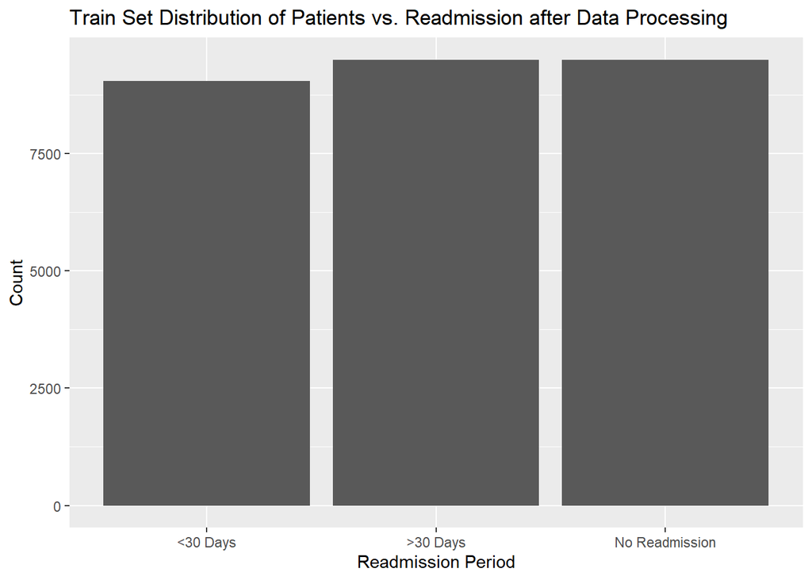

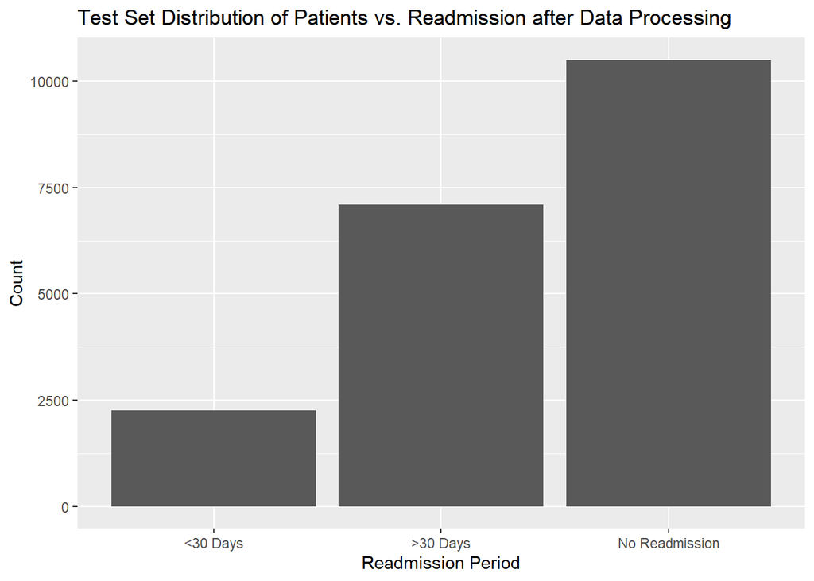

# Classification methods

- Clear description of the methods including (I)
- Tried at least 4 classification algorithms. (ii)
- For classification algorithms requiring parameters, performed parameter tuning.

We have tried the following methods:

- **LightGBM**: Efficient, scalable, accurate, and open-source gradient boosting algorithm that grows leaf-wise. It has been developed using Tidymodels tools (boost_tree, workflow, fit methods). The base model used the default fit method, and later on we did many unsuccessful experiments with optimization (tune_grid method).
- **Random Forest**: Random Forest is highly efficient in solving multi-classification problems due to its ability to handle large datasets with high dimensionality and various feature types. It achieves high accuracy by averaging multiple decsion trees to reduce variance without significant bias.
- **CatBoost**: CatBoost is a open-source machine learning library developed by Yandex. It is based on gradient boosting on decision trees and stands out for its ability to handle categorical features directly without the need for extensive data preprocessing that is typically required by other machine learning algorithms.
- **XGBoost**: XGBoost is an optimized distributed gradient boosting library designed for efficiency, flexibility, and performance. It implements machine learning algorithms under the Gradient Boosting framework. In the parameter tuning process, hyperparameters like learning rate, maximum depth of trees, and number of boosting rounds are tuned.
- **kNN**: kNN is one of the simplest machine learning algorithms. In this project, the kNN model is based on the caret package, using cross-validation to select the best choice of parameter k. The default kNN model’s k is 1.
- **LDA**: LDA is a statistical method for classification. It fits a linear combination of features to maixmize the seperation of different classes.

Cross-validation has been applied throughout most of the models to find the best parameters.

**LightGBM**

```
## Confusion Matrix and Statistics
##
##                 Reference
## Prediction       <30 Days >30 Days No Readmission
##   <30 Days            657     1151            745
##   >30 Days            520     1962            965
##   No Readmission     1086     3988           8796
##
## Overall Statistics
##
##                Accuracy : 0.5745
##                  95% CI : (0.5676, 0.5814)
##     No Information Rate : 0.5287
##     P-Value [Acc > NIR] : < 2.2e-16
##
##                   Kappa : 0.2323
##
##  Mcnemar's Test P-Value : < 2.2e-16
##
## Statistics by Class:
##
##                      Class: <30 Days Class: >30 Days Class: No Readmission
## Sensitivity                  0.29032         0.27630                0.8372
## Specificity                  0.89232         0.88370                0.4581
## Pos Pred Value               0.25734         0.56919                0.6342
## Neg Pred Value               0.90726         0.68709                0.7150
## Prevalence                   0.11389         0.35737                0.5287
## Detection Rate               0.03306         0.09874                0.4427
## Detection Prevalence         0.12849         0.17348                0.6980
## Balanced Accuracy            0.59132         0.58000                0.6477
```

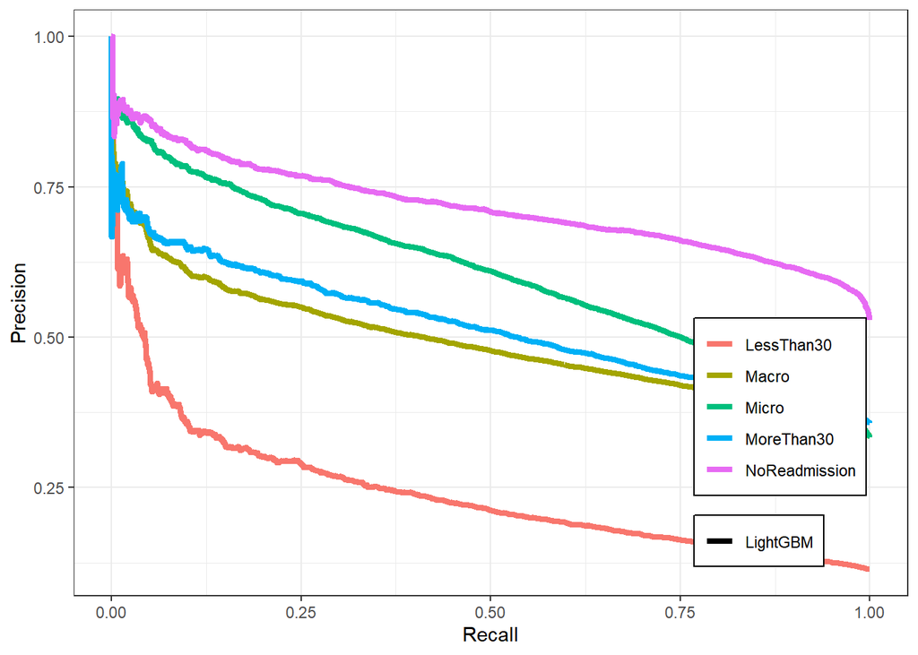

**Random Forest**

```
## Confusion Matrix and Statistics
##
##                 Reference
## Prediction       <30 Days >30 Days No Readmission
##   <30 Days            648     1254            687
##   >30 Days            514     1814            859
##   No Readmission     1101     4033           8960
##
## Overall Statistics
##
##                Accuracy : 0.5748
##                  95% CI : (0.5679, 0.5817)
##     No Information Rate : 0.5287
##     P-Value [Acc > NIR] : < 2.2e-16
##
##                   Kappa : 0.2309
##
##  Mcnemar's Test P-Value : < 2.2e-16
##
## Statistics by Class:
##
##                      Class: <30 Days Class: >30 Days Class: No Readmission
## Sensitivity                  0.28635         0.25546                0.8528
## Specificity                  0.88976         0.89247                0.4517
## Pos Pred Value               0.25029         0.56919                0.6357
## Neg Pred Value               0.90654         0.68309                0.7323
## Prevalence                   0.11389         0.35737                0.5287
## Detection Rate               0.03261         0.09129                0.4509
## Detection Prevalence         0.13030         0.16039                0.7093
## Balanced Accuracy            0.58805         0.57397                0.6523
```

**CatBoost**

```
Author - Wenjing Fan
Last Updated - 13.05.2024
Updated again by Wenjing Fan - 18.05.2024
```

```
## 0:   learn: 0.9437389    test: 0.9426902 best: 0.9426902 (0) total: 340ms    remaining: 340ms
## 1:   learn: 0.9202937    test: 0.9275759 best: 0.9275759 (1) total: 734ms    remaining: 0us
##
## bestTest = 0.9275758754
## bestIteration = 1
```

```
## Confusion Matrix and Statistics
##
##                 Reference
## Prediction       <30 Days >30 Days No Readmission
##   <30 Days            697     1309           1007
##   >30 Days            596     1935           1023
##   No Readmission      970     3857           8476
##
## Overall Statistics
##
##                Accuracy : 0.559
##                  95% CI : (0.5521, 0.566)
##     No Information Rate : 0.5287
##     P-Value [Acc > NIR] : < 2.2e-16
##
##                   Kappa : 0.2193
##
##  Mcnemar's Test P-Value : < 2.2e-16
##
## Statistics by Class:
##
##                      Class: <30 Days Class: >30 Days Class: No Readmission
## Sensitivity                  0.30800         0.27250                0.8068
## Specificity                  0.86846         0.87321                0.4845
## Pos Pred Value               0.23133         0.54446                0.6371
## Neg Pred Value               0.90710         0.68338                0.6909
## Prevalence                   0.11389         0.35737                0.5287
## Detection Rate               0.03508         0.09738                0.4266
## Detection Prevalence         0.15164         0.17886                0.6695
## Balanced Accuracy            0.58823         0.57285                0.6456
```

**XGBoost**

```
Author - Ryan
Last Updated - 19.05.2024
```

```
## Confusion Matrix and Statistics
##
##                       Reference
## Prediction             Less.than.30.Days Greater.than.30.Days No.Readmission
##   Less.than.30.Days                  617                 1058            701
##   Greater.than.30.Days               553                 2005            804
##   No.Readmission                    1093                 4038           9001
##
## Overall Statistics
##
##                Accuracy : 0.585
##                  95% CI : (0.5781, 0.5918)
##     No Information Rate : 0.5287
##     P-Value [Acc > NIR] : < 2.2e-16
##
##                   Kappa : 0.2452
##
##  Mcnemar's Test P-Value : < 2.2e-16
##
## Statistics by Class:
##
##                      Class: Less.than.30.Days Class: Greater.than.30.Days
## Sensitivity                           0.27265                      0.2824
## Specificity                           0.90010                      0.8937
## Pos Pred Value                        0.25968                      0.5964
## Neg Pred Value                        0.90591                      0.6913
## Prevalence                            0.11389                      0.3574
## Detection Rate                        0.03105                      0.1009
## Detection Prevalence                  0.11958                      0.1692
## Balanced Accuracy                     0.58637                      0.5880
##                      Class: No.Readmission
## Sensitivity                         0.8567
## Specificity                         0.4521
## Pos Pred Value                      0.6369
## Neg Pred Value                      0.7377
## Prevalence                          0.5287
## Detection Rate                      0.4530
## Detection Prevalence                0.7112
## Balanced Accuracy                   0.6544
```

**kNN**

```
##                       Sensitivity Specificity Pos Pred Value Neg Pred Value
## Class: <30 Days         0.2841361   0.7762822      0.1403317      0.8940345
## Class: >30 Days         0.3216448   0.7132900      0.3841884      0.6540754
## Class: No Readmission   0.5190367   0.5845792      0.5836455      0.5199962
##                       Precision    Recall        F1 Prevalence Detection Rate
## Class: <30 Days       0.1403317 0.2841361 0.1878744  0.1138903     0.03236034
## Class: >30 Days       0.3841884 0.3216448 0.3501456  0.3573729     0.11494716
## Class: No Readmission 0.5836455 0.5190367 0.5494483  0.5287368     0.27443382
##                       Detection Prevalence Balanced Accuracy
## Class: <30 Days                  0.2305989         0.5302091
## Class: >30 Days                  0.2991948         0.5174674
## Class: No Readmission            0.4702063         0.5518080
```

**LDA**

```
## Confusion Matrix and Statistics
##
##                 Reference
## Prediction       <30 Days >30 Days No Readmission
##   <30 Days            700      273            133
##   >30 Days           2759     2881           1329
##   No Readmission     5592     6349           8041
##
## Overall Statistics
##
##                Accuracy : 0.4142
##                  95% CI : (0.4085, 0.42)
##     No Information Rate : 0.3387
##     P-Value [Acc > NIR] : < 2.2e-16
##
##                   Kappa : 0.1151
##
##  Mcnemar's Test P-Value : < 2.2e-16
##
## Statistics by Class:
##
##                      Class: <30 Days Class: >30 Days Class: No Readmission
## Sensitivity                  0.07734          0.3032                0.8462
## Specificity                  0.97864          0.7797                0.3564
## Pos Pred Value               0.63291          0.4134                0.4024
## Neg Pred Value               0.69014          0.6860                0.8189
## Prevalence                   0.32259          0.3387                0.3387
## Detection Rate               0.02495          0.1027                0.2866
## Detection Prevalence         0.03942          0.2484                0.7122
## Balanced Accuracy            0.52799          0.5414                0.6013
```

# Results

- Completely clear and describe all components of an evaluation process.
- clearly described methods used and the results obtained.
- Clear and thoughtful justification of the final model with informative graphical illustration.
- clearly described the model comparison and the final selected model (if any) based on the proposed evaluation strategies.
- Notice, you need to correctly evaluate the different classification models and consider more than one performance metrics.
- An engaging and clear illustration with discussion.

**Reason for selecting Recall as key performance metric and Precision as a secondary:** Given the critical nature of our healthcare application, specifically aimed at predicting the likelihood of patient readmission, we used ‘Sensitivity’ or ‘Recall’. This metric prioritizes the correct identification of patients at high risk of readmission, which is essential for developing more effective diagnostic and treatment strategies. While this approach may increase the rate of false positives, potentially leading to higher immediate costs for the healthcare system, it significantly enhances patient care by potentially reducing future readmission rates. Such proactive measures can also aid in better hospital capacity management. In this context, the benefits of erring on the side of caution, ensuring that no at-risk patient is overlooked, clearly outweigh the costs. This strategy not only drives improved patient outcomes but also may contribute to overall long-term healthcare system efficiency and cost reduction.

**Models Result:**

| Model/Class | Recall <30 Days | Recall >30 Days | Recall No Readmission | Precision <30 Days | Precision >30 Days | Precision No Readmission | F2 <30 |
| --- | --- | --- | --- | --- | --- | --- | --- |
| LightGBM | 29% | 27.63% | 83.72% | 25.73% | 56.92% | 63.42% | 28.28% |
| Random Forest | 28.64% | 25.55% | 85.3% | 25.03% | 56.92% | 63.57% | 27.84% |
| XGBoost | 27.27% | 28.24% | 85.67% | 25.97% | 59.64% | 63.69% | 26.99% |
| KNN | 28.41% | 32.16% | 51.90% | 14.03% | 38.42% | 58.36% | 23.58% |
| CatBoost | 30.8% | 27.25% | 80.68% | 23.13% | 54.45% | 63.71% | 28.88% |
| LDA | 7.73% | 30.32% | 84.62% | 63.29% | 41.34% | 40.24% | 9.38% |

**the final model**

We have used F2-Measure to select the best model based on Class <30 Days which is the most important one to identify risky patinets, and the model with the highest value is CatBoost with a value close to 30%.

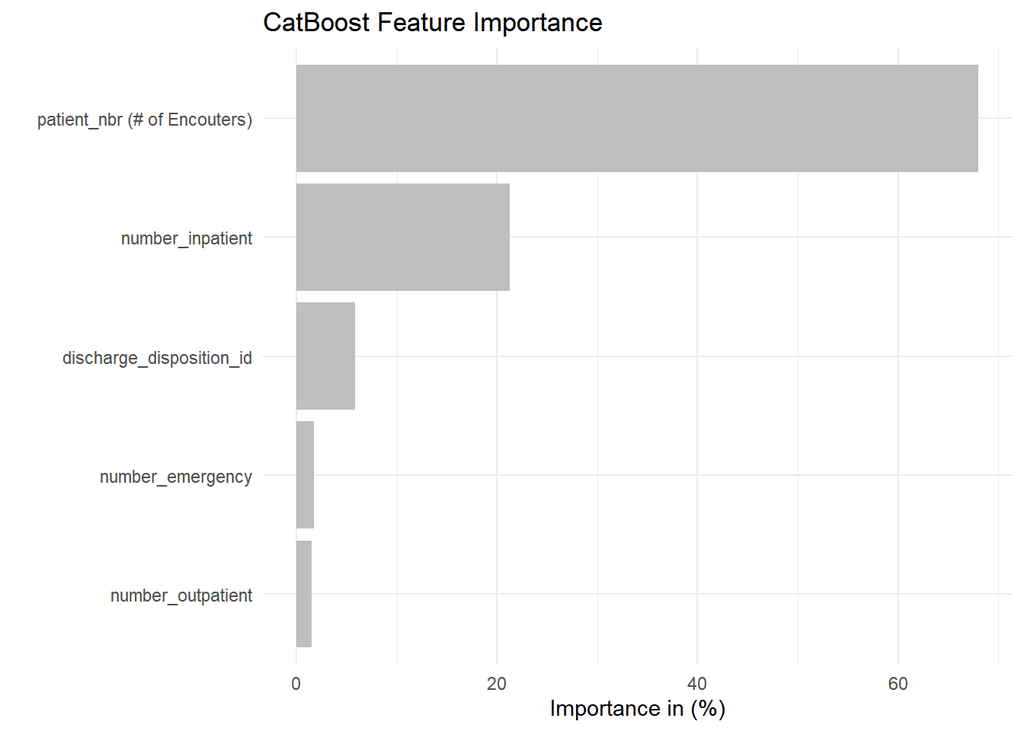

We can see that the most important features are frequency of patient visits to hospital (Encoded Patient Nbr), and number of inpatient for that patient. Hence, the medical history plays important role for the model to make predicition on the status of readmission for a patient.

# Discussion

Modelling Techniques and Development Process:

**Random Forest:** Hyperparameters were optimized iteratively until no significant performance increase was observed.

**KNN:** Parameter ‘k’ was carefully considered to balance model complexity and generalization. Yet, the model suffered from underfitting when ‘k’ exceeded 1, resulting in suboptimal recall for ‘< 30 Days’ class and ‘> 30 Days’ class.

**XGBoost:** The XGBoost model was evaluated using both a base model and a hyperparameter-tuned model. The base model, which used default settings except for 100 boosting rounds. It exhibited balanced performance across the classes but lacked robustness in predicting ‘< 30 Days’ readmissions.In the hyperparameter tuning phase, the tuned model showed a slight improvement, but still faced challenges in predicting ‘< 30 Days’ readmissions.

**CatBoost:** Tuning the six parameters according to the hyperparameter tuning example on the CatBoost R package official website (depth, learning_rate, iterations, l2_leaf_reg, rsm, border_count. border_count remains unchanged, as it relates to CPU or GPU) until there is no significant improvement in performance.

**Linear Discriminant Analysis (LDA):** The Linear Discriminant Analysis (LDA) model was assessed using both a basic configuration with default parameters and a refined version with optimized parameters. While the basic model displayed balanced accuracy particularly for the ‘No Readmission’ class, it encountered difficulties in achieving high recall rates for the ‘< 30 Days’ and ‘> 30 Days’ classes. Despite numerous attempts to fine-tune the model’s hyperparameters, the best-performing optimized model failed to demonstrate significant enhancement over the basic setup. The optimized LDA model continued to struggle with accurately predicting ‘< 30 Days’ and ‘> 30 Days’ readmissions, mirroring the challenges observed in the basic model’s performance.

Issues and Shortcomings:

Despite rigorous development processes, several shortcomings and issues are evident in both the development process and final results:

**Imbalanced Data Handling:** While preprocessing addressed imbalanced data, the resultant models still struggle to accurately predict minority classes, particularly ‘< 30 Days’ readmissions.

Future Work and Improvements:

To address the identified issues and enhance predictive performance, future work should consider the following improvements:

**Advanced Sampling Techniques:** Explore advanced sampling methods such as SMOTE or ADASYN to generate synthetic samples for minority classes, enhancing model generalization and performance.

**Comprehensive Hyperparameter Search:** Conduct more exhaustive hyperparameter searches using techniques like grid search or Bayesian optimization to ensure optimal parameter selection and model robustness.

**Ensemble Approaches:** Investigate ensemble techniques, combining predictions from multiple models to leverage their respective strengths and mitigate individual weaknesses, thus improving overall predictive performance.

**Feature Engineering:** We think the bottleneck of the problem is the data, as the models are very sensitive to any change in the data, and performed close to each other indicating some overfitting. Explore additional feature engineering techniques to extract more informative features or interactions, potentially enhancing model discriminative power and predictive accuracy.

**Clinical Expertise Integration:** Collaborate with domain experts to incorporate domain knowledge into the modelling process, ensuring the relevance and interpretability of the developed models in clinical practice.

# Conclusion

In conclusion, we have done the complete modeling pipeline for a classification problem of patients readmission status. We did data preprocessing with features engineering and downsampling to account for label imbalance, and compared 6 different models result through recall, precision, and F2. The model with highest F2 value is CatBoost, and the most important features were related to history of visits for patient, not HbA1c. while the employed modelling techniques exhibit varying degrees of performance, there are evident shortcomings and areas for improvement in both the development process and final results. Addressing these issues through advanced sampling, comprehensive hyperparameter tuning, ensemble approaches, feature engineering, and integration of clinical expertise can lead to more robust and clinically relevant predictive models for readmission prediction.